# From csv to slippy map: Intro to spatial data in R

Anna Spiers, CU Boulder  
10 August 2021 R Ladies Boulder Chapter Meetup

[figure not shown]

Schneider et al. 2017, *Nat Comm*

**Learning objectives**

1. Describe and identify spatial data
2. Understand the basic differences between the `sp` and `sf` packages
3. Manipulate vector data in R
4. Transform coordinate reference system of data
5. Plot an interactive map of spatial data

### What is spatial data?

[figure not shown]

### What is spatial data?

- Spatial data are data that contain information about a specific location in space, in relative (e.g., two trees are 2m apart) or absolute (e.g., on Earth) terms
- Different types:
  - Vector: graphical respresentations of the world
    - points, lines polygons
    - File type: .shp, .kml, .kmz, .gpx
  - Raster: grid of numbers
    - ex: digital elevation model (DEM), microscope image
    - File type: .tif
  - 3D: three-dimensional
    - point clouds
    - File type: .las, laz

### Vector data

[figure not shown]

### Vector data

- We will work with vector data in this tutorial
- Data types:
  - Points: field sites, state capitols, sensor locations
  - Lines: rivers, division in topography, flight line
  - Polygons: field plot, county boundaries, buffer around a point or line
- Vector data typically store a **geometry** (vertex coordinates) and **attributes** (metadata) for each feature
- File types
  - .shp - [ESRI](https://www.esri.com/en-us/home) developed the shapefile. Consists of several files, so zip them before sharing.
  - .kml/.kmz - Keyole Markup Language. The KML was developed by Keyhole, Inc. which was acquired by Google. It is a simple spatial data format that was originally designed for Google Earth, but now is compatible with non-Google products. A form of XML
  - .gpx - The geopackage is a more modern alternative to the shapefile. You can save different types of spatial data together in one gpx file. Often used in QGIS
  - Many more file types, but we'll stop here
- We will work with shapefiles.
- Attributes are metadata associated with each spatial object

### Case example

- Wog Wog Habitat Fragmentation Experiment

[figure not shown]

- Join me as a graduate student in an Ecology & Evolutionary Biology department. We have the coordinates for the invertebrate pitfall traps across the site. We want to make an interactive map of the field site. How do we do this?
- High-level workflow
  1. CSV with coordinates of traps
  2. Convert CSV to SHP
  3. Plot SHP as map

### Getting started in R: spatial packages

- There are tons of spatial packages
- Two main ones are `sp` and `sf`.
- `sp`
  - First released on CRAN in 2005
  - Offers functionality to create and modify vector data and grids
  - Many (about 350) of R's spatial packages use `sp` as a dependency
  - Made up of 'slots' that describe the spatial object: always a bounding box and coordinate reference system (CRS), but also attributes (e.g., name, soil type, replicate)
  - Examples of `sp` object classes: `SpatialPoints`, `SpatialLines`, `SpatialLinesDataFrame`, `SpatialPolygonsDataFrame`, and more
  - To read in a shapefile: `read_OGR()`

### Getting started in R: spatial packages

- There are tons of spatial packages
- Two main ones are `sp` and `sf`.
- `sf`
  - Stands for 'Simple Features'
  - First released on CRAN in 2016
  - Implements the [WKT (well-known text)](https://en.wikipedia.org/wiki/Well-known_text_representation_of_geometry) format standard
  - Examples of `sf` object classes: `POINT`, `LINESTRING`, `POLYGON`, and more
  - To read in a shapefile: `st_read()` - slightly faster than `read_OGR()`
- Data are structured and conceptualized differently between `sp` and `sf`. Other spatial packages may have different formatting standards and class definitions, but many are built as wrappers around the backbone of `sp` and increasingly more `sf`.

```r
library(sp)
library(sf)
library(rgdal) #readOGR()
library(raster) #crs()
library(tmap)
library(geojsonio)
```

```r
# Load csv
sites <- read.csv("data/example_sites_WGS84.csv")

class(sites)
head(sites)
```

'data.frame'

A data.frame: 6 × 6

|  | name <chr> | lon <dbl> | lat <dbl> | rep <int> | size <chr> | place <chr> |
| --- | --- | --- | --- | --- | --- | --- |
| 1 | 1Sout | 149.4607 | -37.05740 | 1 | S | out |
| 2 | 1Lin | 149.4594 | -37.05986 | 1 | L | in |
| 3 | 1Lout | 149.4576 | -37.06033 | 1 | L | out |
| 4 | 2Sin | 149.4637 | -37.06050 | 2 | S | in |
| 5 | 2Sout | 149.4648 | -37.06004 | 2 | S | out |
| 6 | 2Min | 149.4635 | -37.06196 | 2 | M | in |

```r
# Convert to `sf` spatial object
sites_sf <- sf::st_as_sf(sites, coords=c("lon", "lat"))

# Assign coordinate reference system
st_crs(sites_sf) <- 4326 #epsg code for WGS84

class(sites_sf)
head(sites_sf)
```

1. 'sf'

2. 'data.frame'

A sf: 6 × 5

|  | name <chr> | rep <int> | size <chr> | place <chr> | geometry <POINT [°]> |
| --- | --- | --- | --- | --- | --- |
| 1 | 1Sout | 1 | S | out | POINT (149.4607 -37.0574) |
| 2 | 1Lin | 1 | L | in | POINT (149.4594 -37.05986) |
| 3 | 1Lout | 1 | L | out | POINT (149.4576 -37.06033) |
| 4 | 2Sin | 2 | S | in | POINT (149.4637 -37.0605) |
| 5 | 2Sout | 2 | S | out | POINT (149.4648 -37.06004) |
| 6 | 2Min | 2 | M | in | POINT (149.4635 -37.06196) |

```r
# Load fragment boundaries (already a shp) through `sp` and `sf` packages
frags_sp <- readOGR("data/example_frag_outlines_UTM")
frags_sf <- st_read("data/example_frag_outlines_UTM")
#AIS clear output from this cell in final runthrough
```

```r
# Compare class types for `sp` and `sf` objects

class(frags_sp)

class(frags_sf)
```

'SpatialPolygonsDataFrame'

1. 'sf'

2. 'data.frame'

```r
# Compare `sp` and `sf` objects

frags_sp
head(frags_sp)

head(frags_sf)
```

```
class       : SpatialPolygonsDataFrame
features    : 18
extent      : 718525.6, 719888.8, 5893279, 5895918  (xmin, xmax, ymin, ymax)
crs         : +proj=utm +zone=55 +south +datum=WGS84 +units=m +no_defs
variables   : 2
names       : size, rep
min values  :    L,   0
max values  :    S,   6
```

A data.frame: 6 × 2

|  | size <chr> | rep <chr> |
| --- | --- | --- |
| 0 | L | 3 |
| 1 | S | 3 |
| 2 | M | 3 |
| 3 | M | 4 |
| 4 | L | 4 |
| 5 | S | 4 |

A sf: 6 × 3

|  | size <chr> | rep <dbl> | geometry <POLYGON [m]> |
| --- | --- | --- | --- |
| 1 | L | 3 | POLYGON ((719631.7 5894932,... |
| 2 | S | 3 | POLYGON ((719341.3 5894888,... |
| 3 | M | 3 | POLYGON ((719288.1 5894822,... |
| 4 | M | 4 | POLYGON ((718912.9 5894601,... |
| 5 | L | 4 | POLYGON ((719254.9 5894465,... |
| 6 | S | 4 | POLYGON ((719263.9 5894221,... |

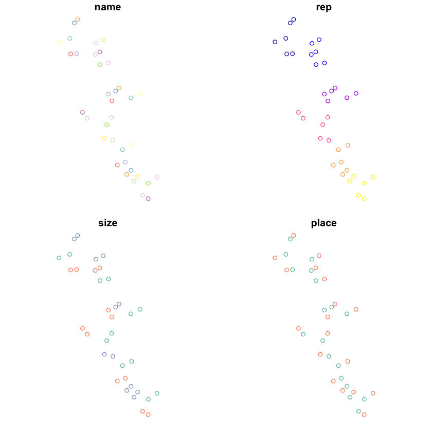

```r
# Going forward, let's use sf objects. I was trained with `sp`, but `sf` seems like the package for the future

# Plot sites
plot(sites_sf)

# Note how the plots are divided into the different attributes for this spatial object
```

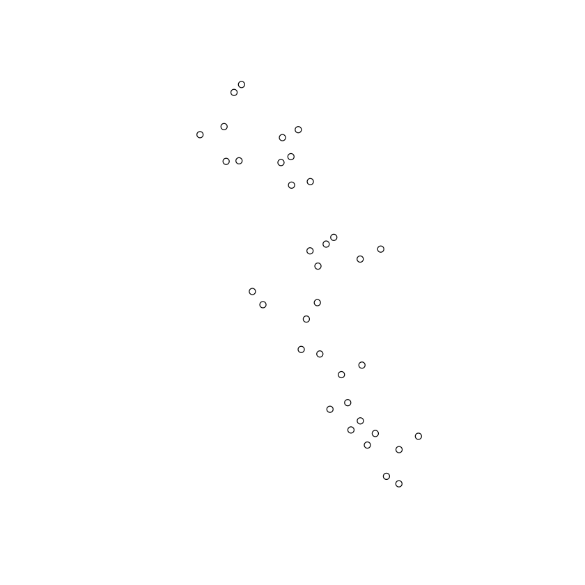

```r
# If you specify only the geometry of the spatial object, then one plot of black points prints

plot(st_geometry(sites_sf))
```

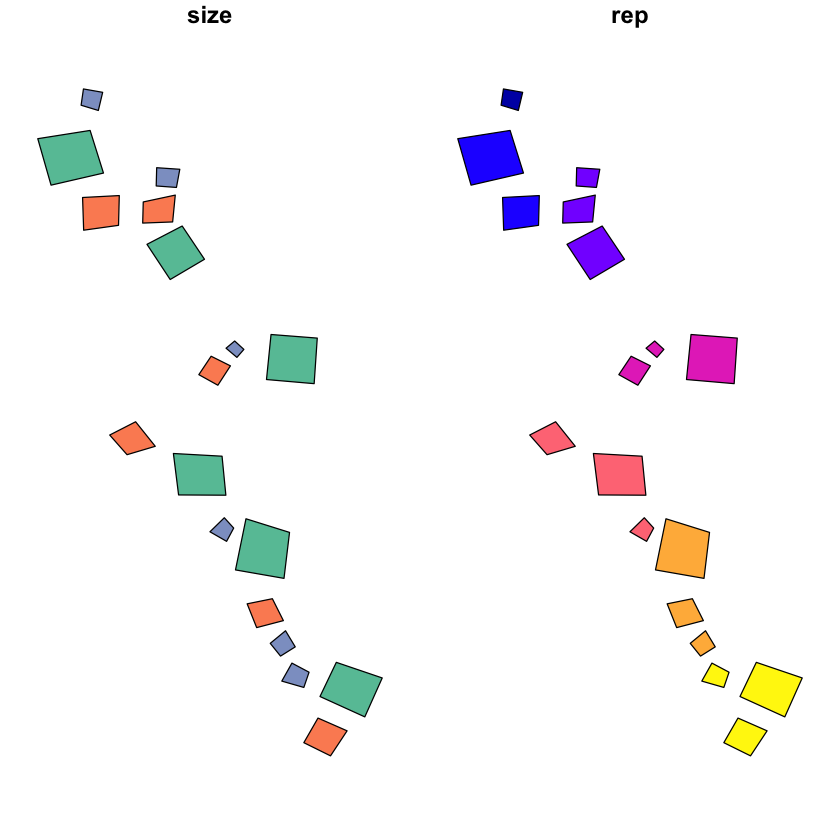

```r
# Plot fragment boundaries
plot(frags_sf)
```

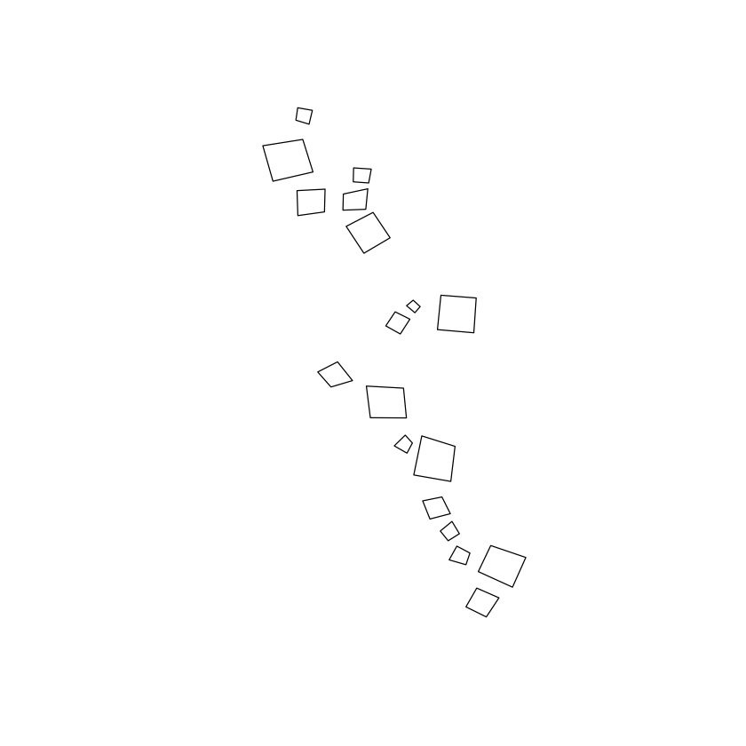

```r
# Specify only the geometry of the fragments
plot(st_geometry(frags_sf))
```

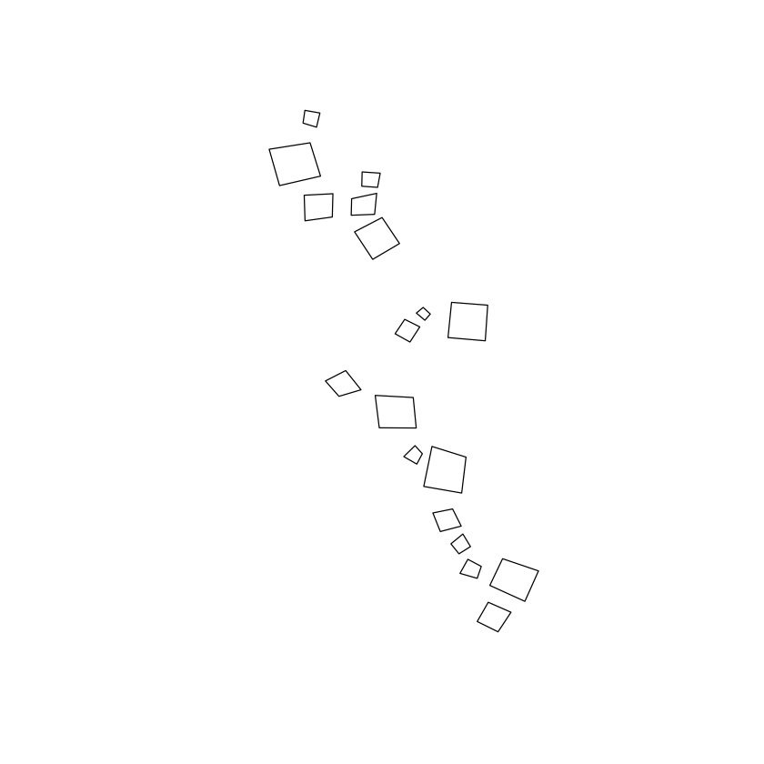

```r
#Plot sites and fragment boundaries together
plot(st_geometry(frags_sf))
plot(st_geometry(sites_sf), pch=19, add=T)

# But why don't we see them together?
```

```r
# Troubleshoot: think to CRS first.
crs(frags_sf)
crs(sites_sf)
# They're different. The fragments are in a UTM projection
```

```
CRS arguments:
 +proj=utm +zone=55 +south +datum=WGS84 +units=m +no_defs
```

```
CRS arguments: +proj=longlat +datum=WGS84 +no_defs
```

### Brief glimpse at Coordinate Reference Systems

- Coordinate reference systems (CRS) are either projected or unprojected
  - Unprojected (i.e. global, geographic)
    - curved representations of Earth
    - great for visualizing large areas (e.g., spanning countries)
    - e.g., Google Earth
  - Projected
    - flat projection of curved surface
    - good for spatial analyses (i.e. more precise local measurements)
    - e.g., paper map, Google Maps
- Two common CRS: UTM (projected) and WGS84 (geographic)

### Brief glimpse at Coordinate Reference Systems

- UTM Zones across USA. CO is in UTM Zone 13N
- Site coordinates at Wog Wog are in UTM Zone 55S

[figure not shown]

- There is so much more to CRS, but this is all we'll cover

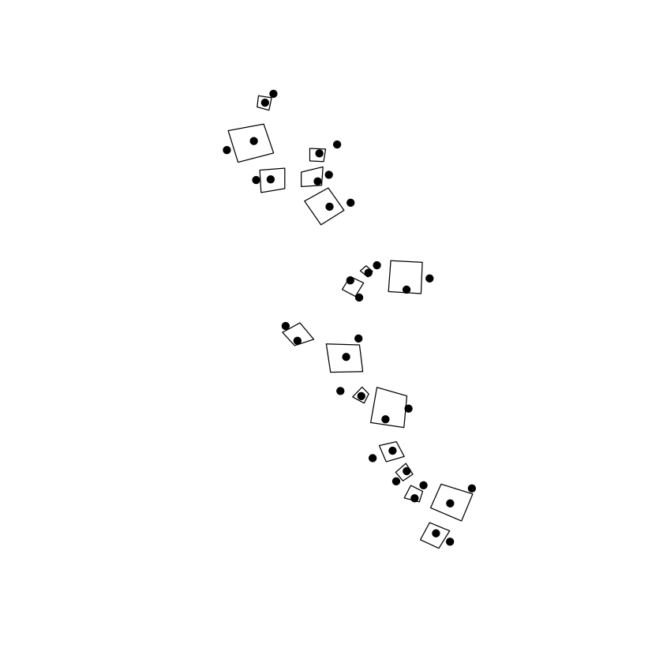

```r
# Transform fragments object to have same CRS as sites
frags_sf_reproj <- st_transform(frags_sf, 4326)

# Now plot fragments and sites together
plot(st_geometry(frags_sf_reproj))
plot(st_geometry(sites_sf), pch=19, add=T)
```

### Mapping

- This map is sufficient for a basic visualization, but we can do better.
- Our objective is to create an interactive map so we can explore our field site more easily. Now that we have our spatial data loaded in R and formatted properly, we can start building a map.
- There are many ways to plot interactive maps, like `plotly` or `leaflet`. We will use `tmap`, which isn't compatible in jupyter notebook.

```r
# Embed your map in a webpage:
# <iframe src="/figures/wogwog_esribackdrop.html" frameborder=0,  height=400, width="100%", scrolling="no"></iframe>
```

### Extra tips

- Visualize your data in a GIS as a sanity check before plotting in R or doing analyses. I recommend QGIS since it's open source. Also, store all your data in one GIS project.
- Create spatial data online using [geojson.io](https://geojson.io/)
- If you need to convert your data into a crazy CRS, try [NOAA's Vertical Datum tool](https://www.vdatum.noaa.gov/)
- Create animated maps where data changes through time using [this resource](https://geocompr.robinlovelace.net/adv-map.html)
- Great resource for geospatial data handling and analysis: [EarthDataScience](https://www.earthdatascience.org/). It is based out of CU's Earth Lab and has spatial data lessons in both R and Python.
- For students, the university library often has a spatial librarian. Phil White at CU is great.
- As always, stackoverflow and your spatially-oriented friends are great resources
- [The guide](https://medium.com/learning-machine-learning/present-your-data-science-projects-with-jupyter-slides-75f20735eb0f) I used for using Jupyter Notebook slides

### Questions?

https://github.com/annaspiers/spatial-data_mapping_RLadies

While we're at it, another cool map...

[figure not shown]